# Chapter 3 Data Visualisation

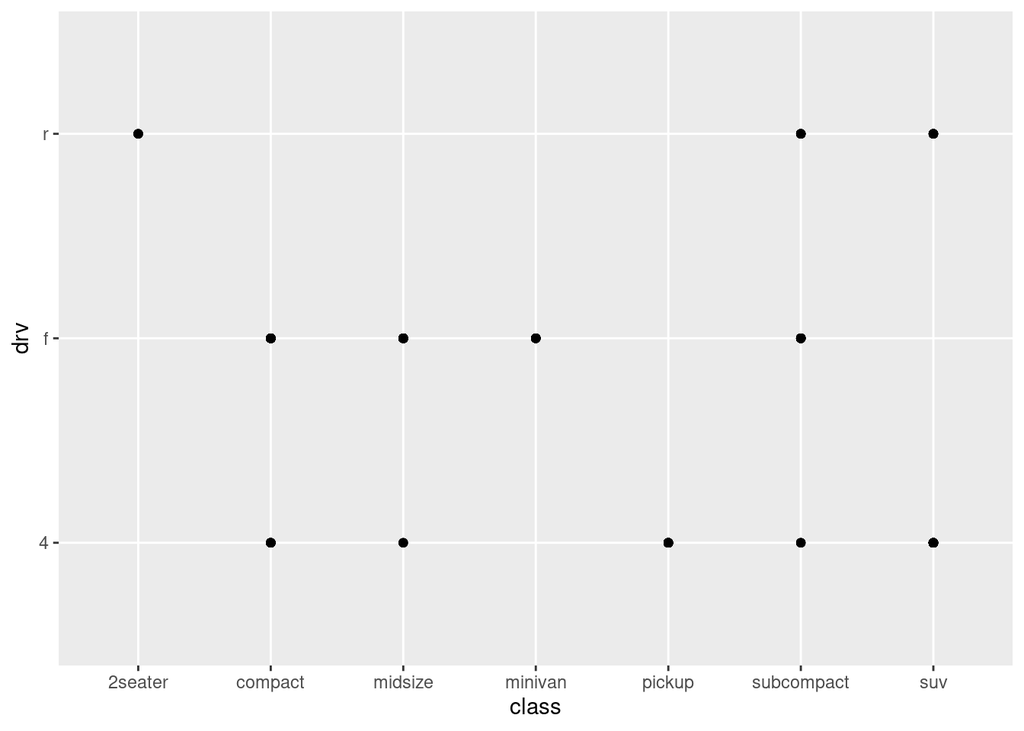

```r
ggplot(data = mpg)+
  geom_point(mapping = aes(x = class, y = drv))
```

Plot is for graphing Geometry is the type of graph Aesthetics are the visual representations on the graph. This determines aspects like color, size, or shape. Different data types can be distinguished this way.

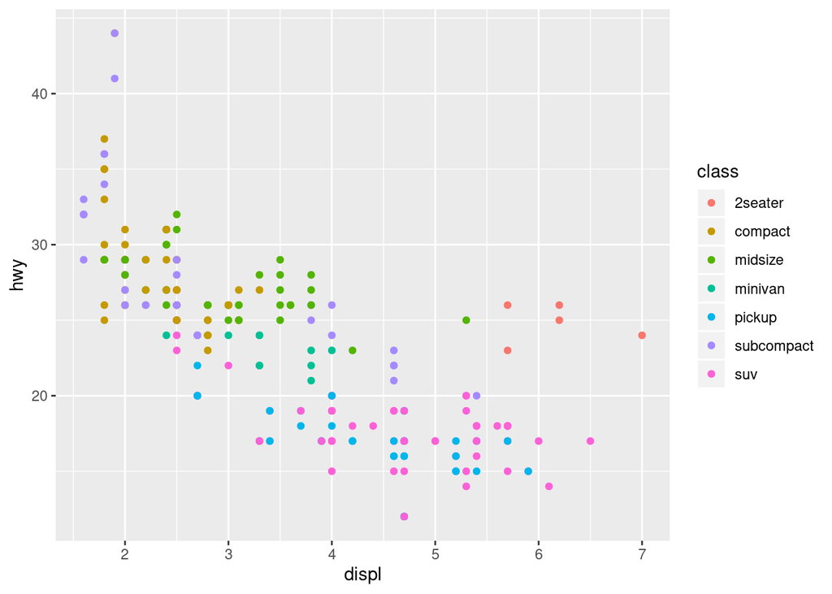

```r
ggplot(data = mpg) +
  geom_point(mapping = aes(x = displ, y = hwy, color = class))
```

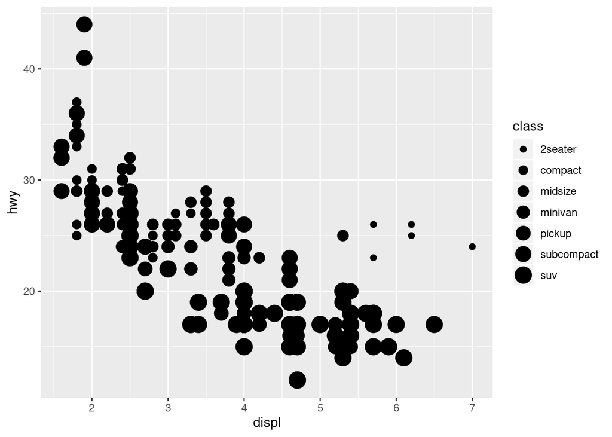

```r
ggplot(data = mpg)+
  geom_point(mapping =aes(x = displ, y = hwy, size = class))
```

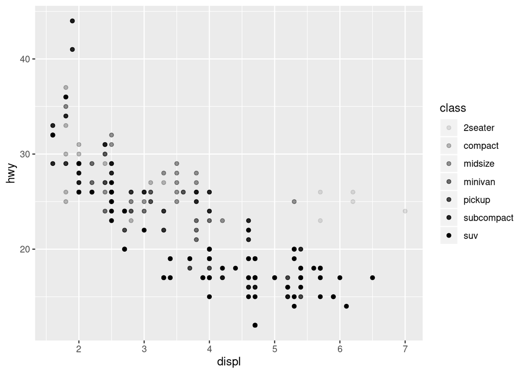

```r
ggplot(data = mpg)+
  geom_point(mapping =aes(x = displ, y = hwy, alpha = class))
```

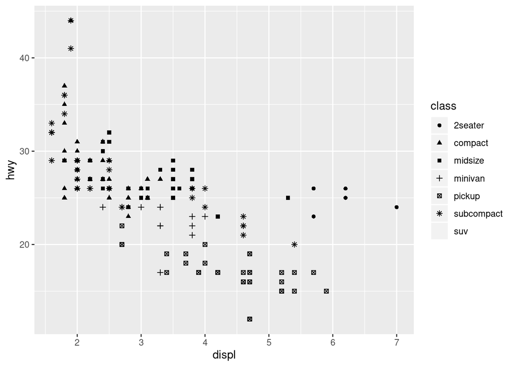

```r
ggplot(data = mpg)+
  geom_point(mapping =aes(x = displ, y = hwy, shape = class))
```

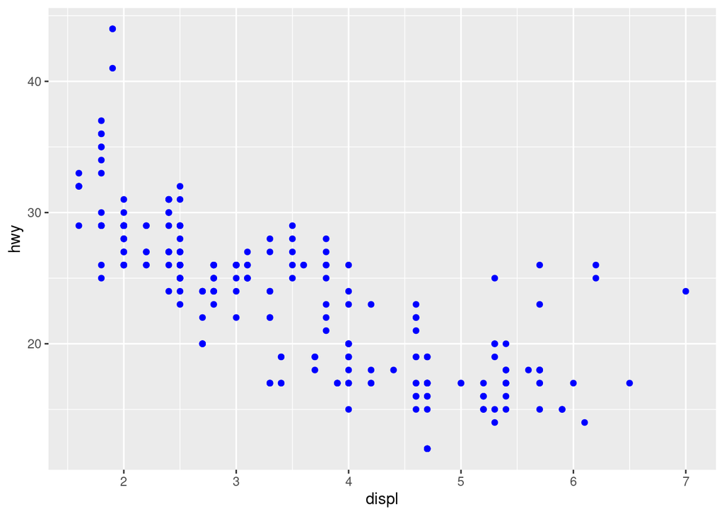

```r
ggplot(data = mpg)+
  geom_point(mapping =aes(x = displ, y = hwy), color = "blue")
```

Exercise 1: The colors are not blue because color should be placed outside of aes

Exercise 2: Model, trans, drv, fl, class, and maybe year are all categorical.

Exercise 3: They shift along with the axis

Exercise 4: Multiple aesthetics get applied to the points.

Exercise 5: Stroke controls the outline around a shape.

Exercise 6: returns an error

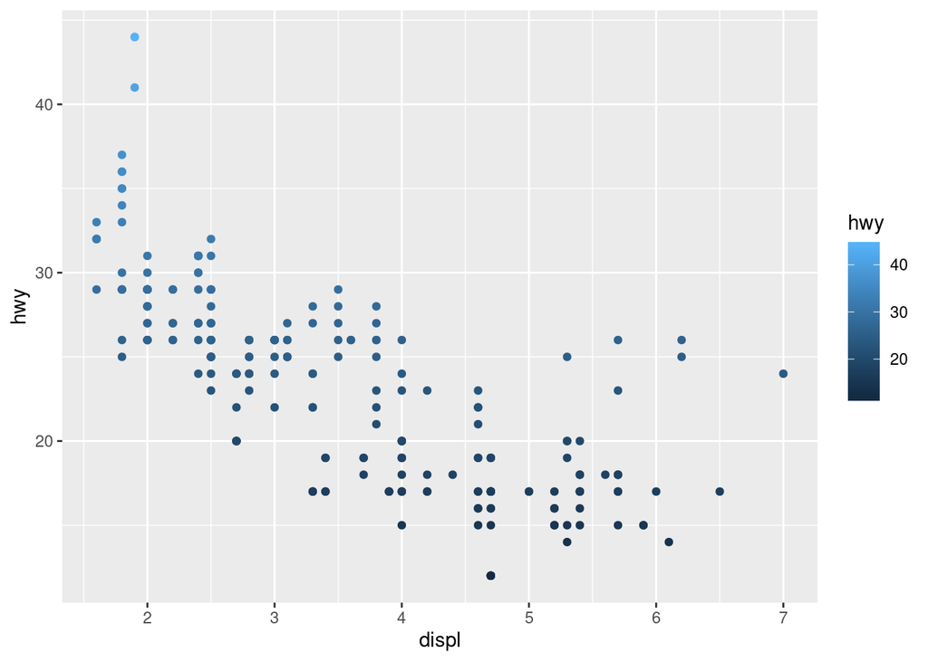

```r
ggplot(data = mpg)+
  geom_point(mapping =aes(x = displ, y = hwy, color = hwy))
```

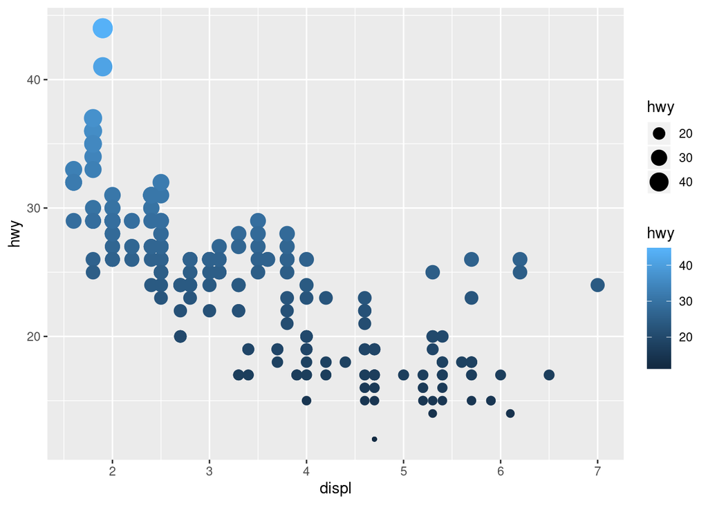

```r
ggplot(data = mpg)+
  geom_point(mapping =aes(x = displ, y = hwy, size = hwy, color = hwy))
```

## Facets you can split categorical data into separate subplots called a facet

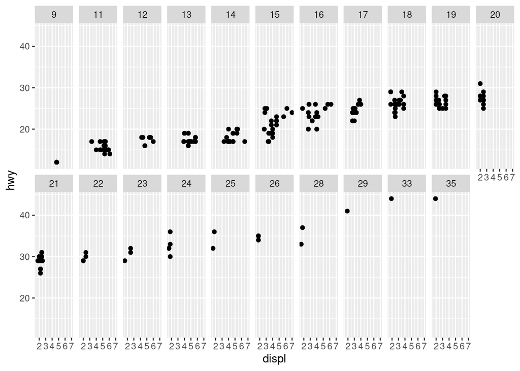

```r
ggplot(data = mpg)+
  geom_point(mapping = aes(x = displ, y= hwy)) +
  facet_wrap(~ cty, nrow = 2)
```

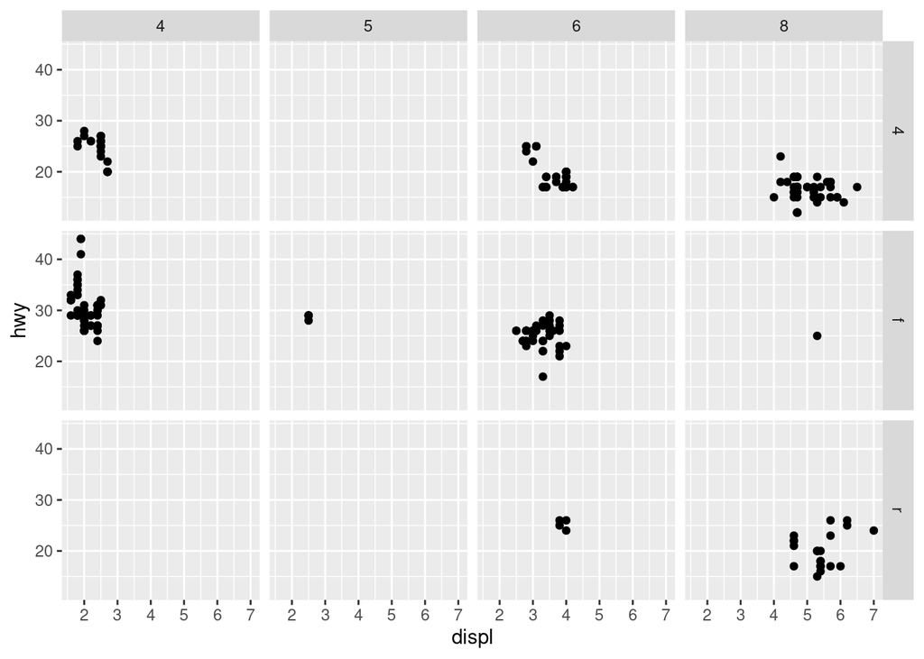

```r
ggplot(data = mpg)+
  geom_point(mapping = aes(x = displ, y= hwy)) +
  facet_grid(drv ~ cyl)
```

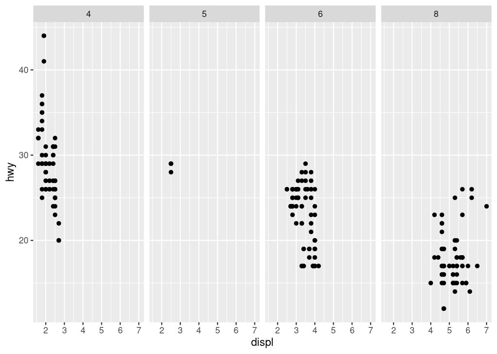

```r
ggplot(data = mpg)+
  geom_point(mapping = aes(x = displ, y= hwy)) +
  facet_grid(. ~ cyl)
```

3.5.1 1. It breaks the plot up and makes what looks like a trend across the graphs. 2. It means there is no engines of that many cylinders with that type of drive system. 3. The first one includes a subplot with drive systems, the second cylinders. The period means to not plot anything in that axis for additional facet subplots. 4. The advantage to using facets is that it makes trends within a specific sub-plot more easily viewable. The disadvantage is that it becomes more difficult to view connections with the rest of the data. If the data set is large enough the points might look random until split up. 5.nrow and ncol determine the number of rows and columns.Labeller, each output line displayed as one separate line in the strip label. 6. Facet grid will show graphs even if there is no data for them, while facet wrap will display only the ones that have a graph.

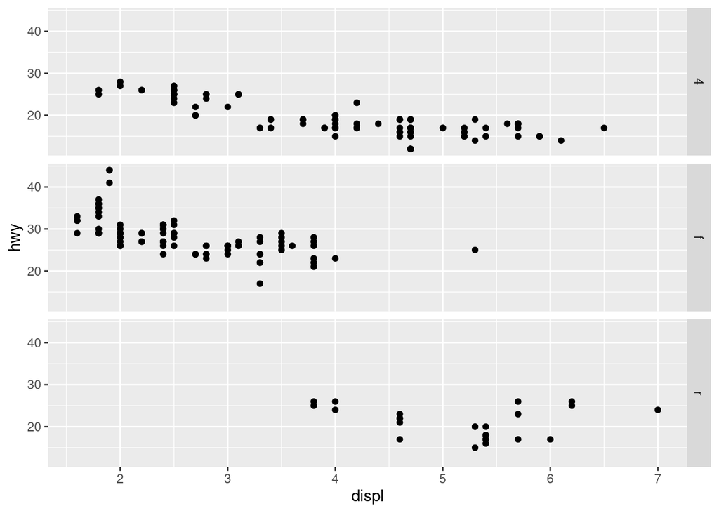

```r
ggplot(data = mpg) +
  geom_point(mapping = aes(x = displ, y = hwy))+
  facet_grid(drv ~ .)
```

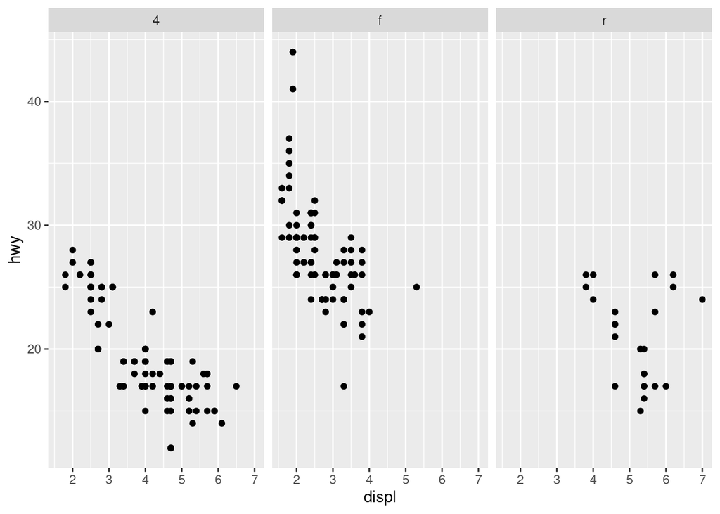

```r
ggplot(data = mpg) +
  geom_point(mapping = aes(x = displ, y = hwy))+
  facet_wrap(drv ~ .)
```

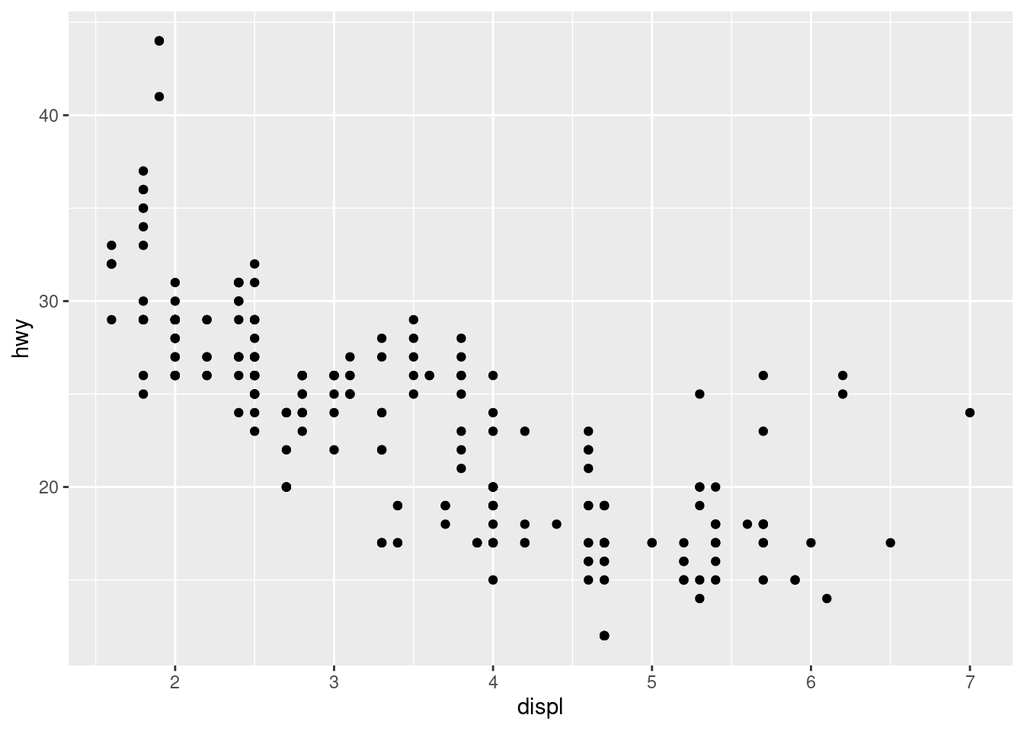

```r
ggplot(data = mpg)+
  geom_point(mapping = aes (x = displ, y = hwy))
```

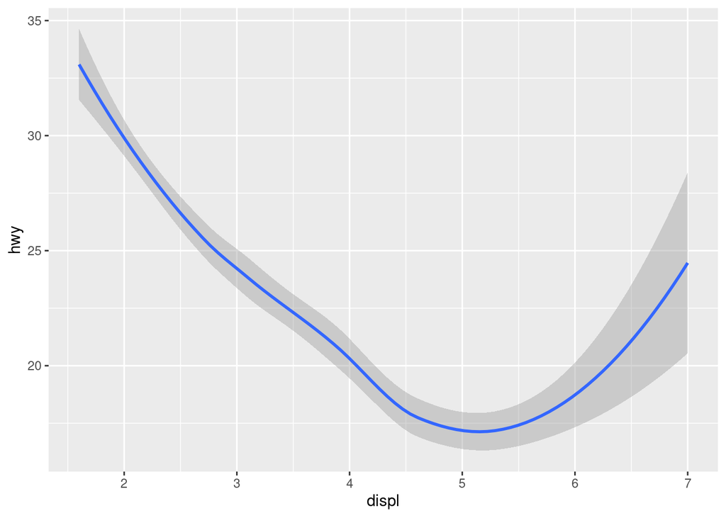

```r
ggplot(data = mpg)+
  geom_smooth(mapping = aes (x = displ, y = hwy))
```

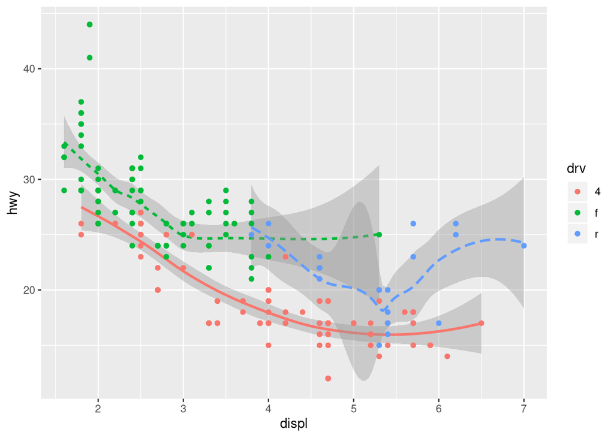

```r
ggplot(data = mpg)+
  geom_smooth(mapping = aes (x = displ, y = hwy, color = drv, linetype = drv),show.legend = FALSE)+
  geom_point(mapping = aes(x = displ, y =hwy, color = drv))
```

A better way to graph You can also sepecify to graph different data

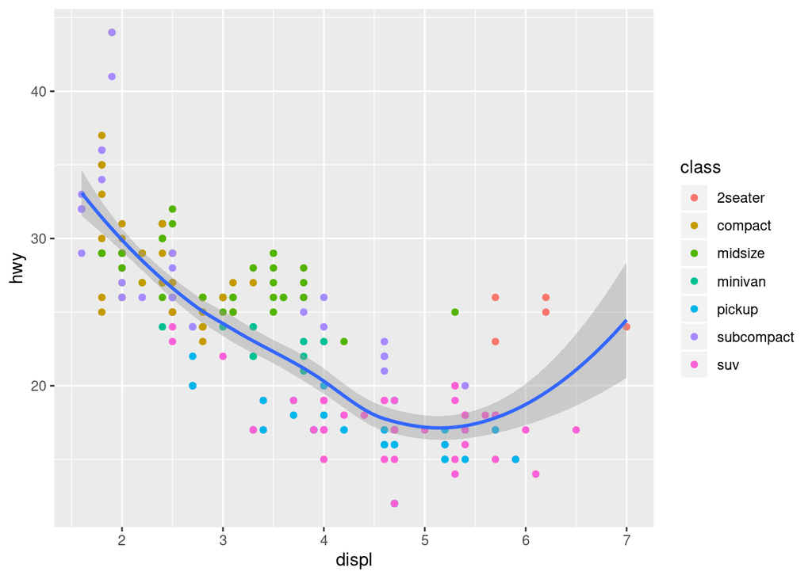

```r
ggplot(data = mpg, mapping = aes(x = displ, y = hwy))+
  geom_point(mapping = aes(color = class)) +
  geom_smooth()
```

3.6.1 1.

```r
#geom_line(),geom_boxplot(),geom_histogram(),geom_area()
```

or path/smooth 2.

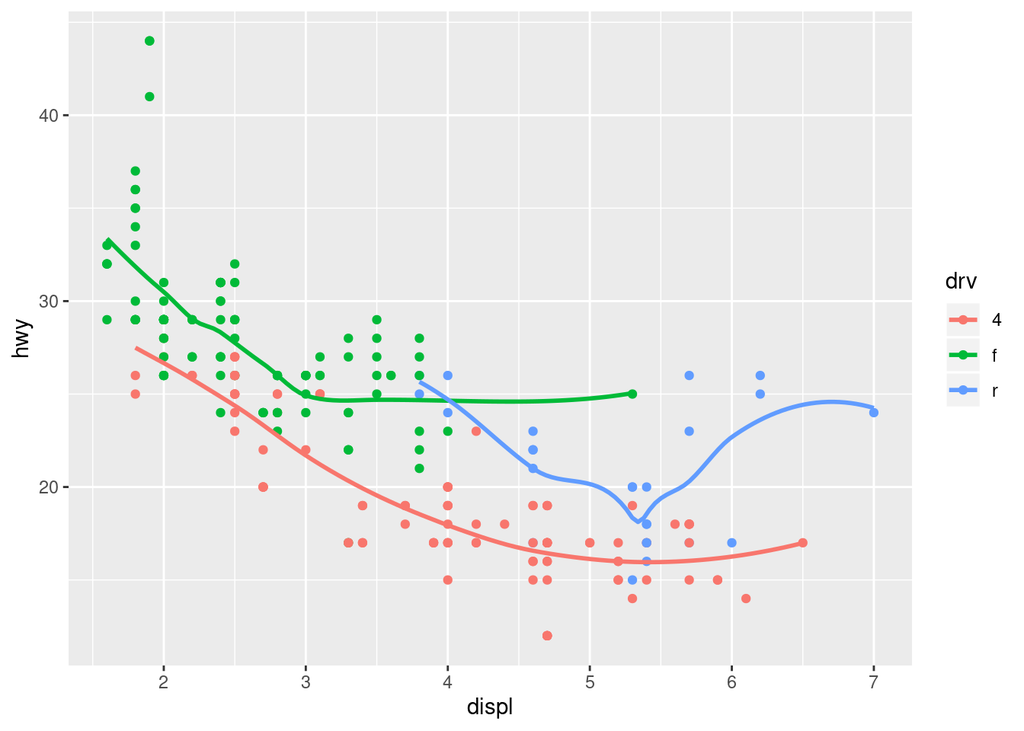

```r
ggplot(data = mpg, mapping = aes(x =displ, y=hwy, color =drv))+
  geom_point()+
  geom_smooth(se = FALSE)
```

3. This will hide the legend. Sometimes the legend is redundant based on the labels. 4. This displays the confidence interval. 5. They will look the same, you can reduce duplicate data by placing the aes in ggplot 6.

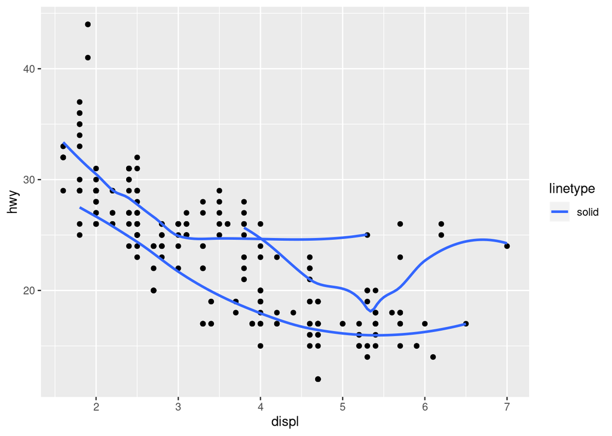

```r
ggplot(data = mpg, mapping = aes(x=displ, y=hwy, linetype = "solid"))+
  geom_point(mapping = aes(),color="black")+
  geom_smooth(se = FALSE, mapping = aes(group=drv))
```

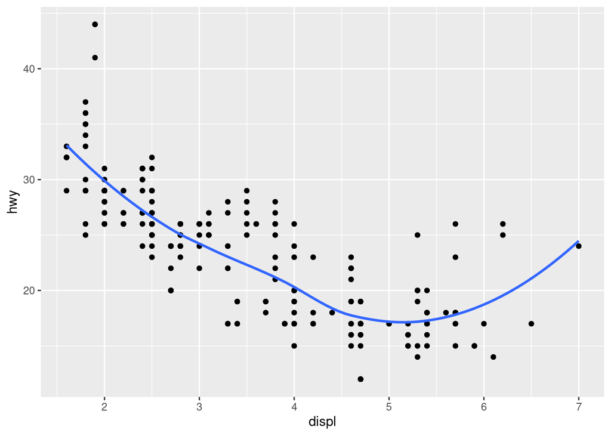

```r
ggplot(data = mpg, mapping = aes(x=displ, y=hwy))+
  geom_point(mapping = aes(),color="black")+
  geom_smooth(se = FALSE)
```

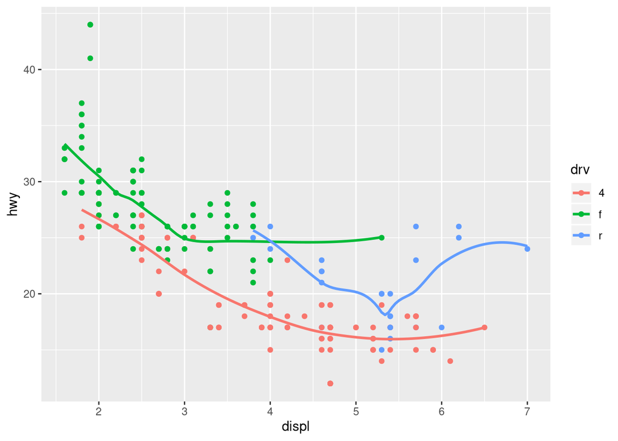

```r
ggplot(data = mpg, mapping = aes(x=displ, y=hwy, color= drv))+
  geom_point(mapping = aes())+
  geom_smooth(se = FALSE)
```

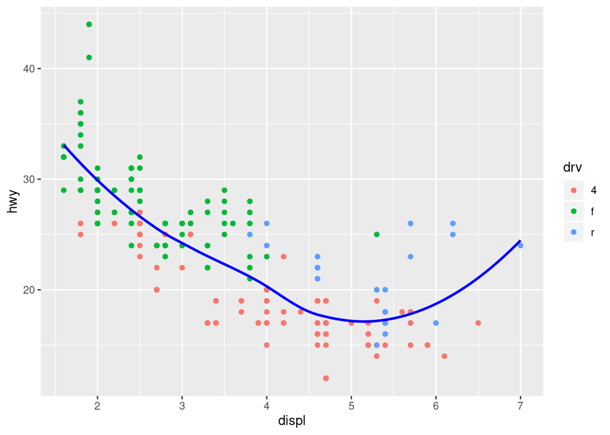

```r
ggplot(data = mpg, mapping = aes(x=displ, y=hwy,color = drv))+
  geom_point()+
  geom_smooth(se = FALSE, color = "blue")
```

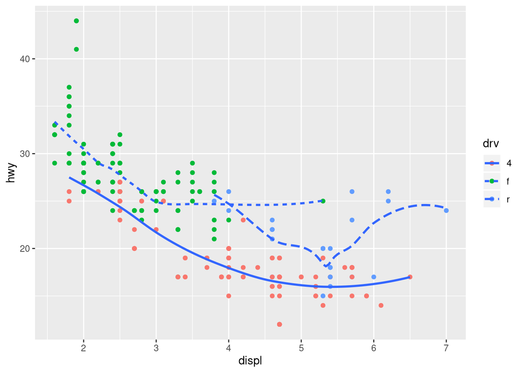

```r
ggplot(data = mpg, mapping = aes(x=displ, y=hwy))+
  geom_point(mapping = aes(color=drv))+
  geom_smooth(se = FALSE, mapping = aes(linetype = drv))
```

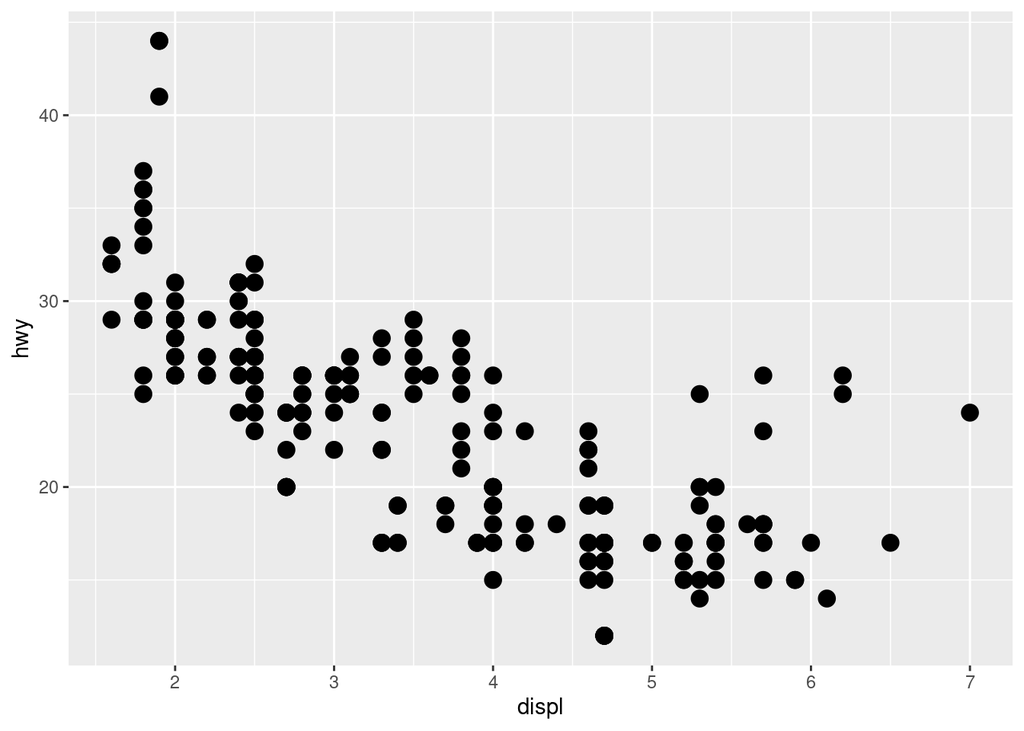

```r
ggplot(data = mpg, stroke =2, size =4, mapping = aes(x=displ, y=hwy))+
  geom_point(stroke = 2, )
```

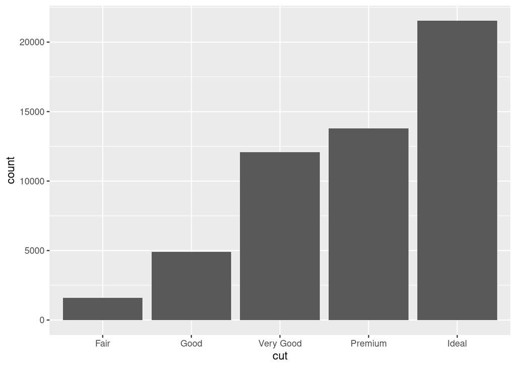

```r
ggplot(data = diamonds) +
  geom_bar(mapping = aes(x = cut))
```

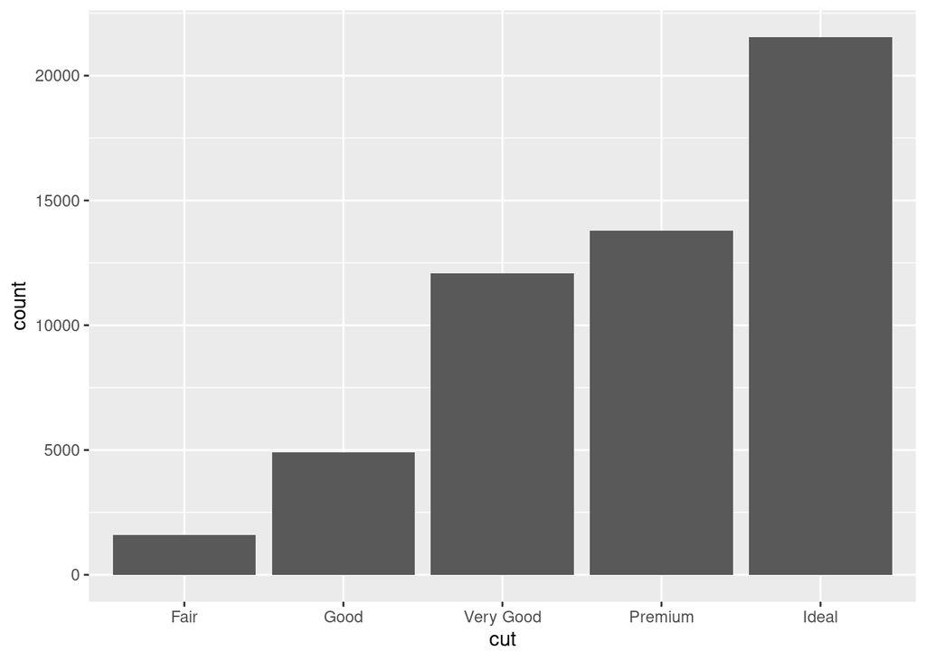

```r
ggplot(data=diamonds)+
  stat_count(mapping = aes(x = cut))
```

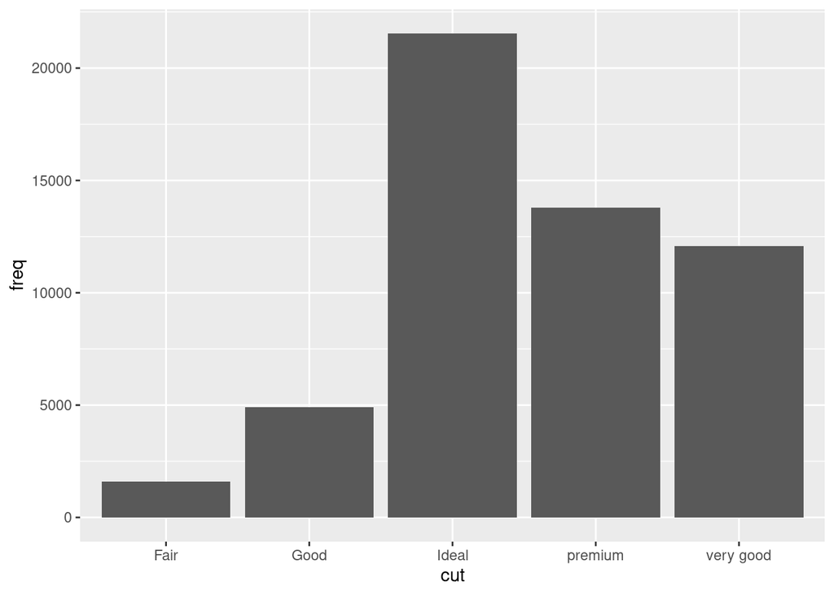

```r
demo <- tribble(
  ~cut, ~freq,
  "Fair", 1610,
  "Good", 4906,
  "very good", 12082,
  "premium", 13791,
  "Ideal", 21551
)

ggplot(data = demo) +
  geom_bar(mapping = aes(x = cut, y = freq), stat = "identity")
```

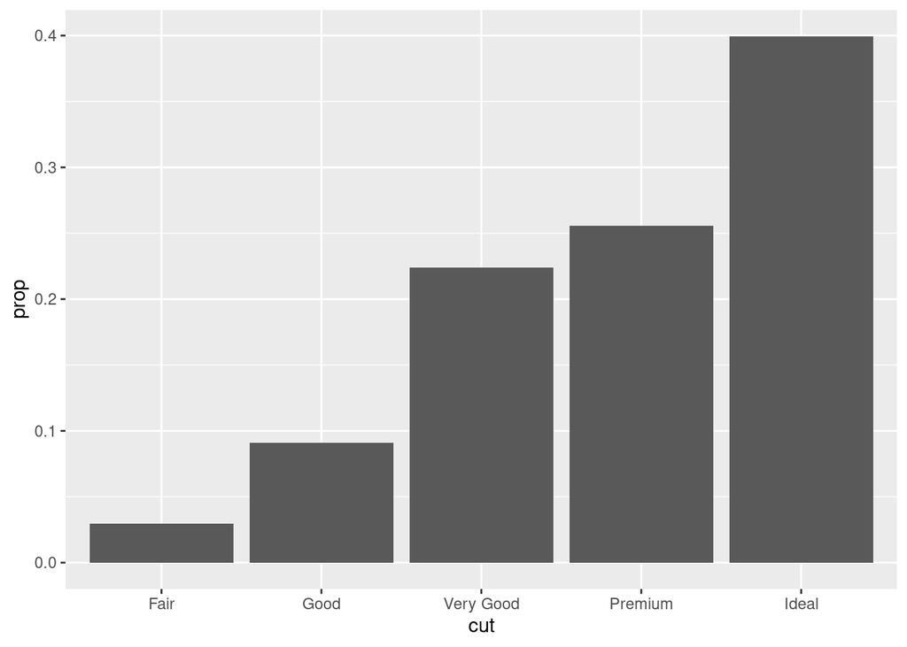

```r
ggplot(data = diamonds) +
  geom_bar(mapping = aes(x = cut, y = ..prop.., group =1))
```